# SL_Project_Part_ONE

## Supervised Learning Project Part-ONE

## 0. Importing all the necessary libraries:

```python
#Necessary libraries for EDA
import pandas as pd             #Package for analysing data
import numpy as np              #General-purpose array-processing package
import seaborn as sns           #For plotting graphs which is built on matplotlib
import matplotlib.pyplot as plt #For plotting graphs
%matplotlib inline
import warnings
warnings.filterwarnings('ignore')
```

Necessary libraries for Machine learning

```python
from sklearn.preprocessing import LabelEncoder   #Encode target labels with value between 0 and n_classes-1.
from sklearn.model_selection import train_test_split #Split arrays or matrices into random train and test subsets
from sklearn.metrics import precision_recall_fscore_support, mean_absolute_error #Library of statistical functions
from sklearn.metrics import accuracy_score, confusion_matrix, classification_report
from sklearn.preprocessing import StandardScaler #Standardize features by removing the mean and scaling to unit variance
from sklearn.preprocessing import MinMaxScaler   #Transform features by scaling each feature to a given range.
from sklearn.neighbors import KNeighborsClassifier#Classifier implementing the k-nearest neighbors vote
```

## 1.Import and warehouse data:

Loading and appending the datasets

```python
df1 = pd.read_csv('Part1 - Normal.csv')  #read the csv file
df2 = pd.read_csv('Part1 - Type_S.csv')  #read the csv file
df3 = pd.read_csv('Part1 - Type_H.csv')  #read the csv file
print("The Size of df1 is :",df1.size,"and the Shape is :",df1.shape) #get size and shape of the dataset
print("The Size of df2 is :",df2.size,"and the Shape is :",df2.shape) #get size and shape of the dataset
print("The Size of df3 is :",df3.size,"and the Shape is :",df3.shape) #get size and shape of the dataset
```

```
The Size of df1 is : 700 and the Shape is : (100, 7)
The Size of df2 is : 1050 and the Shape is : (150, 7)
The Size of df3 is : 420 and the Shape is : (60, 7)
```

```python
df = pd.concat([df1,df2,df3],ignore_index= True) #Concatenate pandas objects along a particular axis with optional set logic along the other axes
row, column = df.shape
print('The final Dataset contains',row,"rows and",column,"columns")
print('The size of the final dataset is :',df.size)
```

```
The final Dataset contains 310 rows and 7 columns
The size of the final dataset is : 2170
```

```python
df.head(5)
```

|  | P_incidence | P_tilt | L_angle | S_slope | P_radius | S_Degree | Class |
| --- | --- | --- | --- | --- | --- | --- | --- |
| 0 | 38.505273 | 16.964297 | 35.112814 | 21.540976 | 127.632875 | 7.986683 | Normal |
| 1 | 54.920858 | 18.968430 | 51.601455 | 35.952428 | 125.846646 | 2.001642 | Normal |
| 2 | 44.362490 | 8.945435 | 46.902096 | 35.417055 | 129.220682 | 4.994195 | Normal |
| 3 | 48.318931 | 17.452121 | 48.000000 | 30.866809 | 128.980308 | -0.910941 | Normal |
| 4 | 45.701789 | 10.659859 | 42.577846 | 35.041929 | 130.178314 | -3.388910 | Normal |

## 2. Data cleaning:

```python
print('Null values:\n',df.isnull().sum()) #finds the null values in the dataset
```

```
Null values:
 P_incidence    0
P_tilt         0
L_angle        0
S_slope        0
P_radius       0
S_Degree       0
Class          0
dtype: int64
```

```python
df['Class'].value_counts().to_frame() #There should be only three classes. "Normal", "Type_S", "Type_H"
```

|  | Class |
| --- | --- |
| Type_S | 133 |
| Normal | 73 |
| Type_H | 37 |
| Nrmal | 27 |
| type_h | 23 |
| tp_s | 17 |

```python
df.Class.replace(['Nrmal','Normal'],'Normal',inplace = True) #Replacing the wrongly represented data to correct format
df.Class.replace(['tp_s','Type_S'],'Type_S',inplace = True)  #Replacing the wrongly represented data to correct format
df.Class.replace(['type_h','Type_H'],'Type_H',inplace = True)#Replacing the wrongly represented data to correct format
df.Class.unique()                                            #Return unique values of Series object
```

```
array(['Normal', 'Type_S', 'Type_H'], dtype=object)
```

```python
df.tail()  #display of last rows of the dataframe
```

|  | P_incidence | P_tilt | L_angle | S_slope | P_radius | S_Degree | Class |
| --- | --- | --- | --- | --- | --- | --- | --- |
| 305 | 47.657730 | 13.277385 | 36.679985 | 34.380345 | 98.249781 | 6.273012 | Type_H |
| 306 | 43.349606 | 7.467469 | 28.065483 | 35.882137 | 112.776187 | 5.753277 | Type_H |
| 307 | 46.855781 | 15.351514 | 38.000000 | 31.504267 | 116.250917 | 1.662706 | Type_H |
| 308 | 43.203185 | 19.663146 | 35.000000 | 23.540039 | 124.846109 | -2.919076 | Type_H |
| 309 | 48.109236 | 14.930725 | 35.564683 | 33.178512 | 124.056452 | 7.947905 | Type_H |

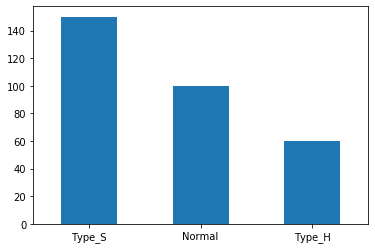

```python
df.Class.value_counts().plot(kind = 'bar', rot=0)
```

```python
((df['Class'].value_counts() / df.shape[0]) * 100).head(10)
```

```
Type_S    48.387097
Normal    32.258065
Type_H    19.354839
Name: Class, dtype: float64
```

Some imbalance in the data is observed as 48.38% of the samples are of **Type_S** followed by **Normal** type with 32.25% and **Type_H** with only 19.34% which could effect the performace of the model and since it's a healthcare field it's important to balce the data.

## 3. Data analysis & visualisation:

```python
df.describe().T  #since we can describe the data of all numerical class,we can assume that there are no null_values or wrongly represented data
```

|  | count | mean | std | min | 25% | 50% | 75% | max |
| --- | --- | --- | --- | --- | --- | --- | --- | --- |
| P_incidence | 310.0 | 60.496653 | 17.236520 | 26.147921 | 46.430294 | 58.691038 | 72.877696 | 129.834041 |
| P_tilt | 310.0 | 17.542822 | 10.008330 | -6.554948 | 10.667069 | 16.357689 | 22.120395 | 49.431864 |
| L_angle | 310.0 | 51.930930 | 18.554064 | 14.000000 | 37.000000 | 49.562398 | 63.000000 | 125.742385 |
| S_slope | 310.0 | 42.953831 | 13.423102 | 13.366931 | 33.347122 | 42.404912 | 52.695888 | 121.429566 |
| P_radius | 310.0 | 117.920655 | 13.317377 | 70.082575 | 110.709196 | 118.268178 | 125.467674 | 163.071041 |
| S_Degree | 310.0 | 26.296694 | 37.559027 | -11.058179 | 1.603727 | 11.767934 | 41.287352 | 418.543082 |

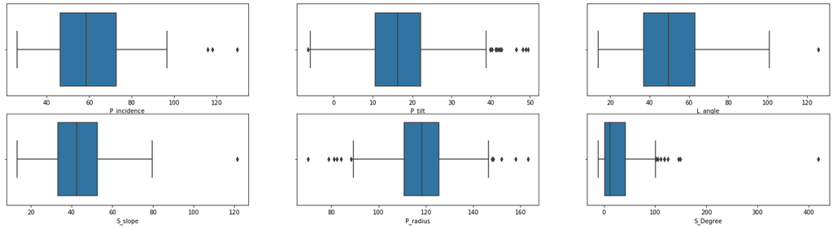

```python
plt.figure(figsize=(25, 20))
col = 1
for i in df.drop(columns = 'Class').columns:
    plt.subplot(6, 3, col)
    sns.boxplot(df[i])
    col += 1
```

```python
for col_name in df.drop(columns = 'Class').columns:     # Dropping the outliers
    q1 = df[col_name].quantile(0.25)
    q3 = df[col_name].quantile(0.75)
    iqr = q3 - q1

    low = q1 - 1.5 * iqr
    high = q3 + 1.5 * iqr

    df.loc[(df[col_name] < low) | (df[col_name] > high), col_name] = df[col_name].median()
```

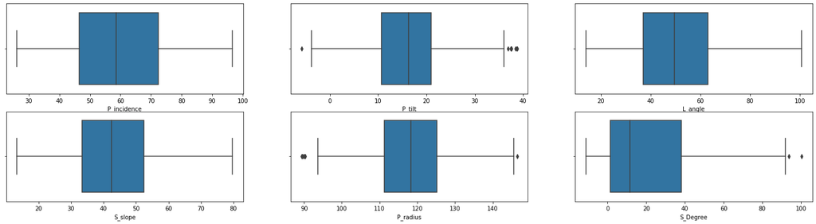

```python
plt.figure(figsize=(25, 20))
col = 1
for i in df.drop(columns = 'Class').columns:
    plt.subplot(6, 3, col)
    sns.boxplot(df[i])
    col += 1
```

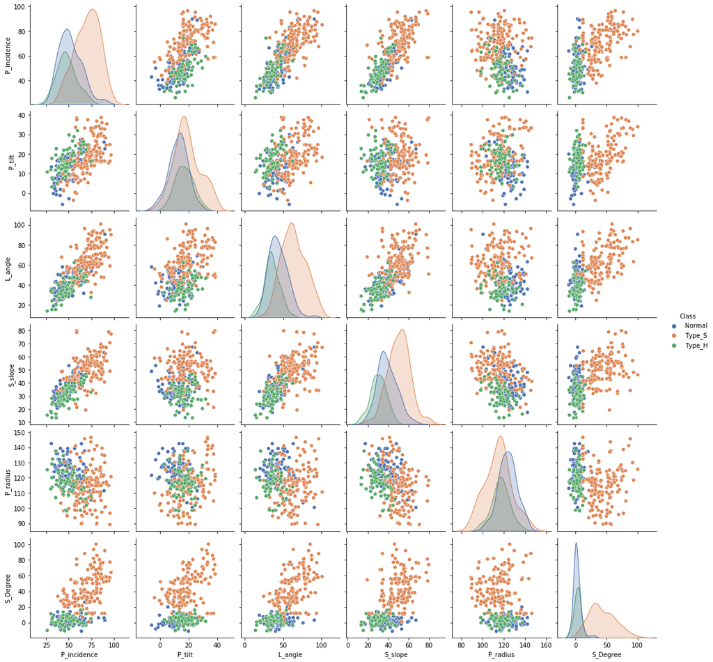

```python
sns.pairplot(df,hue='Class',palette="deep")         #Plot pairwise relationships in a dataset
```

#### Inference:

Pairplot is useful to visualize the distribution of a variable or the relationship between multiple variables separately within subsets of the dataset.

- Linear relationship is observed between P_incidence and P_tilt, L_angle, S_slope.
- Linear relationship is observed between L_angle and S_slope.

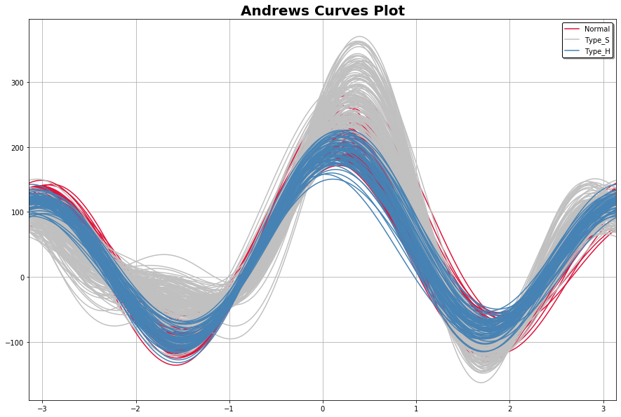

```python
from pandas.plotting import andrews_curves
plt.figure(figsize=(15,10))
andrews_curves(df, "Class", color=['crimson','silver','steelblue'],samples=200)
plt.title('Andrews Curves Plot', fontsize=20, fontweight='bold')
plt.legend(loc=1, prop={'size': 10}, frameon=True,shadow=True, facecolor="white", edgecolor="black")
plt.show()
```

Andrews curves allows to plot multivariate data as a large number of curves that are created using the attributes of samples as coefficients for Fourier series. By coloring these curves differently for each class it is possible to visualize data clustering. Curves belonging to samples of the same class will usually be closer together and form larger structures.

```python
correlation = df.corr()
correlation
```

|  | P_incidence | P_tilt | L_angle | S_slope | P_radius | S_Degree |
| --- | --- | --- | --- | --- | --- | --- |
| P_incidence | 1.000000 | 0.582003 | 0.775086 | 0.769339 | -0.243391 | 0.649893 |
| P_tilt | 0.582003 | 1.000000 | 0.412124 | 0.158176 | 0.057835 | 0.394989 |
| L_angle | 0.775086 | 0.412124 | 1.000000 | 0.678666 | -0.099942 | 0.688491 |
| S_slope | 0.769339 | 0.158176 | 0.678666 | 1.000000 | -0.349644 | 0.573594 |
| P_radius | -0.243391 | 0.057835 | -0.099942 | -0.349644 | 1.000000 | -0.196789 |
| S_Degree | 0.649893 | 0.394989 | 0.688491 | 0.573594 | -0.196789 | 1.000000 |

df.corr() computes pairwise correlation of columns.

- Correlation shows how two variables are related to each other.
- Positive values shows as one variable increases other variable increases as well.
- Negative values shows as one variable increases other variable decreases.
- Bigger values show high correlation between variables while smaller values show less correlation.

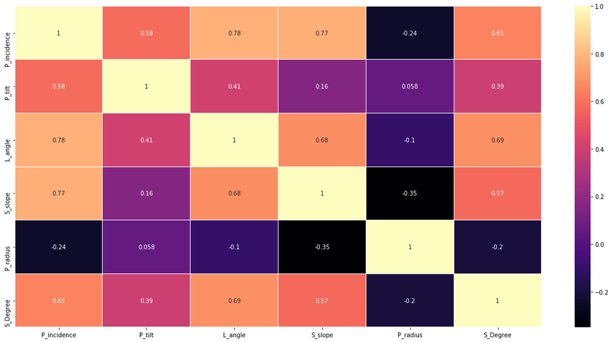

```python
fig,ax = plt.subplots(figsize=(20,10))
ax=sns.heatmap(df.corr(),annot=True,linewidths=0.01,fmt='.2g',cmap="magma")  #Plot rectangular data as a color-encoded matrix
bottom,top = ax.get_ylim()
ax.set_ylim(bottom + 0.5, top - 0.5)
plt.show()
```

```python
le = LabelEncoder()                         #Encode target labels with value between 0 and n_classes-1
df['Class'] = le.fit_transform(df['Class']) #Fit label encoder and return encoded labels
```

```python
((df['Class'].value_counts() / df.shape[0]) * 100).head(10)
```

```
2    48.387097
0    32.258065
1    19.354839
Name: Class, dtype: float64
```

Since the labels are categorical. KNeighborsClassifier does not accept string labels.Hence conversion is done to transform them into numbers.**Normal to 0**, **Type_S to 2** and **Type_H correspond to 1**.

## 4. Data Pre-processing:

```python
X = df.drop(['Class'], axis=1, inplace=False)  #Features
y = df['Class']                                #Target
```

The dataset contains 7 columns : **P_incidence**, **P_tilt**, **L_angle**, **S_slope**,**P_radius**,**S_Degree** and **Class**.

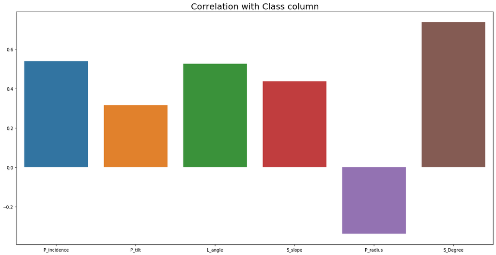

```python
plt.figure(figsize = (20, 10))
sns.barplot(x = X.columns, y = X.corrwith(y))
plt.title('Correlation with Class column', fontsize = 20)
```

#### Inference:

- Except **P_radius** all other features follow a positive corelation with the target variable **Class**

```python
scaler = MinMaxScaler(copy=True, feature_range=(0, 1))  #Transform features by scaling each feature to a given range.
X = scaler.fit_transform(X)
```

Using MinMaxScaler to standardize the values of each column. This is required in order to bring the input variables on same scale, which might be on different scales in the raw form.

### Spliting data into training and testing set

```python
X_train, X_test, y_train, y_test = train_test_split(X, y, test_size = 0.2, random_state = 123)
```

```python
y_train.value_counts()
```

[output not shown]

```python
y.value_counts()
```

```
2    150
0    100
1     60
Name: Class, dtype: int64
```

```python
print("Before OverSampling, counts of label '2': {} \n".format(sum(y_train == 2)))
print("Before OverSampling, counts of label '1': {}".format(sum(y_train == 1)))
print("Before OverSampling, counts of label '0': {} \n".format(sum(y_train == 0)))

from imblearn.over_sampling import SMOTE
sm = SMOTE(random_state = 2)
X_train_res, y_train_res = sm.fit_sample(X_train, y_train)

print('After OverSampling, the shape of train_X: {}'.format(X_train_res.shape))
print('After OverSampling, the shape of train_y: {} \n'.format(y_train_res.shape))

print("After OverSampling, counts of label '2': {}".format(sum(y_train_res == 2)))
print("After OverSampling, counts of label '1': {}".format(sum(y_train_res == 1)))
print("After OverSampling, counts of label '0': {}".format(sum(y_train_res == 0)))
```

```
Before OverSampling, counts of label '2': 120

Before OverSampling, counts of label '1': 48
Before OverSampling, counts of label '0': 80

After OverSampling, the shape of train_X: (360, 6)
After OverSampling, the shape of train_y: (360,)

After OverSampling, counts of label '2': 120
After OverSampling, counts of label '1': 120
After OverSampling, counts of label '0': 120
```

## 5. Model training, testing and tuning:

```python
classifier = KNeighborsClassifier(n_neighbors=3) #Instantiate learning model(K=3)
```

```python
classifier.fit(X_train_res, y_train_res)                  #Fitting the model
```

```
KNeighborsClassifier(algorithm='auto', leaf_size=30, metric='minkowski',
                     metric_params=None, n_jobs=None, n_neighbors=3, p=2,
                     weights='uniform')
```

```python
classifier.score(X_train_res, y_train_res) #Classification accuracy for Train data
```

```
0.9611111111111111
```

```python
classifier.score(X_test,y_test)           #Classification accuracy for Test data
```

```
0.8548387096774194
```

```python
y_pred = classifier.predict(X_test)
```

```python
cm = confusion_matrix(y_test, y_pred)    #Compute confusion matrix to evaluate the accuracy of a classification
cm
```

```
array([[17,  2,  1],
       [ 4,  8,  0],
       [ 2,  0, 28]])
```

```python
accuracy = accuracy_score(y_test, y_pred)*100
print('Accuracy of the Model is equal to ' + str(round(accuracy, 2)) + ' %.')
```

```
Accuracy of the Model is equal to 85.48 %.
```

```python
neig = np.arange(1,25)            # Finding the best k value
train_accuracy = []
test_accuracy = []
for i, k in enumerate(neig):      # Loop over different values of k
    knn = KNeighborsClassifier(n_neighbors=k,weights='distance')
    knn.fit(X_train_res,y_train_res)
    prediction = knn.predict(X_test)
    train_accuracy.append(knn.score(X_train_res, y_train_res))
    test_accuracy.append(knn.score(X_test, y_test))
print("Best accuracy is {} with K = {}".format(np.max(test_accuracy)*100,1+test_accuracy.index(np.max(test_accuracy))))
```

```
Best accuracy is 88.70967741935483 with K = 5
```

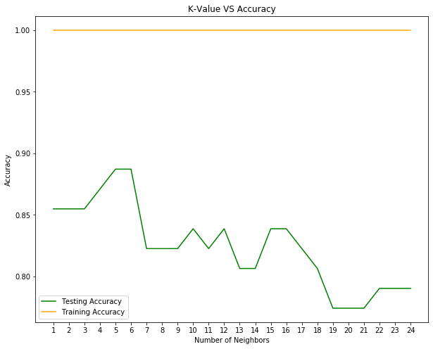

```python
plt.figure(figsize=[10,8])
plt.plot(neig, test_accuracy, color="green", label = 'Testing Accuracy')
plt.plot(neig, train_accuracy, color="orange", label = 'Training Accuracy')
plt.legend()
plt.title('K-Value VS Accuracy')
plt.xlabel('Number of Neighbors')
plt.ylabel('Accuracy')
plt.xticks(neig)
plt.show()
```

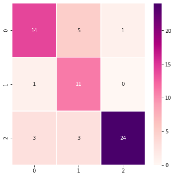

```python
cm_knn = confusion_matrix(y_test,prediction)      ##Compute confusion matrix to evaluate the accuracy of a classification

f,ax = plt.subplots(figsize = (6,6))
sns.heatmap(cm_knn,annot=True,linewidths=0.5,fmt = ".0f", cmap = "RdPu" , ax= ax)
bottom,top = ax.get_ylim()
ax.set_ylim(bottom + 0.5, top - 0.5)
plt.show()
```

```python
print(classification_report(y_test,prediction))
```

```
              precision    recall  f1-score   support

           0       0.78      0.70      0.74        20
           1       0.58      0.92      0.71        12
           2       0.96      0.80      0.87        30

    accuracy                           0.79        62
   macro avg       0.77      0.81      0.77        62
weighted avg       0.83      0.79      0.80        62
```

## 6. Conclusion:

- The Accuracy of the KNN model with K=3 is 85.48%.
- The Accuracy of the KNN model with **K=5** is found to be the best fit model with score of **88.70%** which is almost 4 percent more than regular KNN model.
- **Type_H** has a recall of 92%, which means that among the patients with Type_H condition The KNN model predicted 92% of them to have Type_H condition.
- **Type_S** has recall of 80%, which means that among the patients with Type_S condition The KNN model predicted 80% of them to have Type_S condition.
- **type_S** has a precision of 96%, The model predicted the correct type 96% times. we can infer that the model has done really well in prediction Type_S condition as it has high recall and precision.
- For **Noraml** condition the model predicted 78% of the data correctly.

  ```
       +++++++++++++++++++++++++++++++++++++++++++++++++++++++++++++++++++++++++++
  ```

#### Suggestions for Future Data collection:

- Clearer description and understanding of what the features means should be provided for better analysis and feature engineering.
- More data should be recorded from patients as the sample-set was too low (310) to build a usable model for prediction.
- Much better results can be obtained if the target had only two classes **Normal** and **Abnormal** on the given 310 datapoints.
- Various methods should be implemented to record more data and addition of new features from X-rays, CT-scans and MRI's.